[figure not shown]

# **SEGUIDORES y AMIGOS de LOS CANDIDATOS**

#### **José Manuel Magallanes Ph.D.**

[CRÉDITOS y CONDICIONES DE USO](https://rawgit.com/projectsUW/peru2016elections/master/Credits.html)

En Twitter, se dice que usuario tiene *seguidores* y *amigos*. Un seguidor es quien decide seguir lo que el usuario publica en su Twitter; mientras que un *amigo* es aquel a quien el usuario sigue.

Veamos la situación que se tenía en ambos casos para los candidatos a Lima:

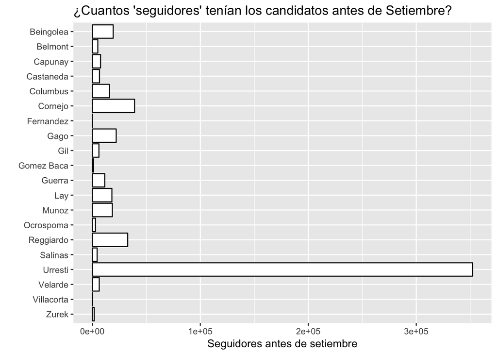

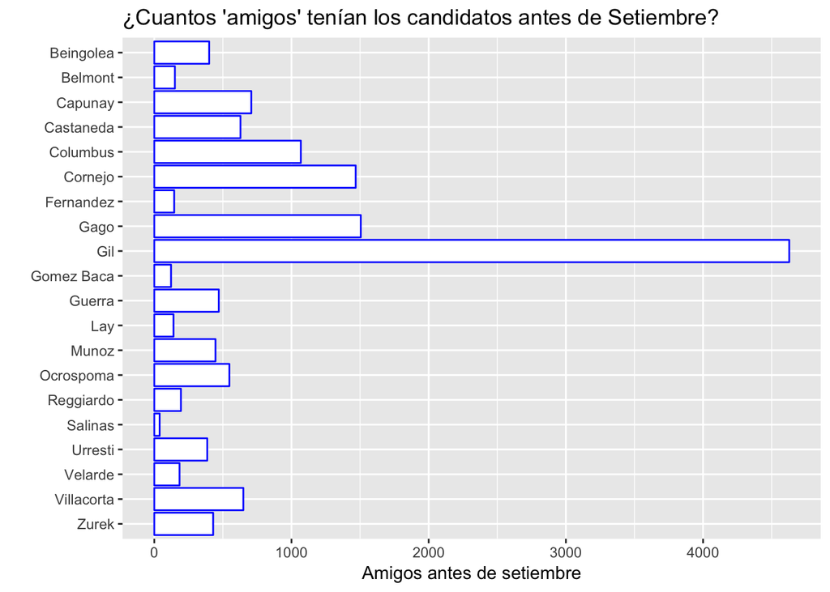

Dada la situación electoral, prestemos atención al crecimiento de seguidores a partir del mes de setiembre:

[figure not shown]

## Quiénes siguen a los seguidores:

La siguiente tabla da información resumen sobre los *antecedentes* de seguimiento de los seguidores de los candidatos. Así, se nota que hay seguidores que tienen muchos seguidores en la mayoría de los casos:

|  | candiname | total | max_SeguidoPor | min_SeguidoPor | max_SeguidoPor_90pct |
| --- | --- | --- | --- | --- | --- |
| 1 | BeingoleaA | 19537 | 2907451 | 0 | 503 |
| 2 | DanielUrresti1 | 270373 | 3561685 | 0 | 77 |
| 3 | DitelColumbus | 15988 | 3564051 | 0 | 706 |
| 4 | ENRIQUECORNEJOR | 39226 | 3563785 | 0 | 409 |
| 5 | EnriquePorLima | 58 | 49952 | 0 | 2373 |
| 6 | EstherCapunay | 7837 | 2570228 | 0 | 857 |
| 7 | GGG_pe | 12853 | 2570943 | 0 | 746 |
| 8 | GomezBacaxLima | 1039 | 352848 | 0 | 899 |
| 9 | humberto_lay | 18171 | 2570273 | 0 | 532 |
| 10 | jaimesalinas80 | 4445 | 2253509 | 0 | 1118 |
| 11 | JorgeMunozAP | 18920 | 3563940 | 0 | 676 |
| 12 | JoseLuisGil1000 | 6267 | 1541010 | 0 | 1409 |
| 13 | juancarloszurek | 1715 | 2571058 | 0 | 1169 |
| 14 | JulioGagoPe | 22039 | 2571040 | 0 | 509 |
| 15 | kikeocrospoma | 2906 | 958088 | 0 | 620 |
| 16 | luchocastanedap | 6673 | 3563485 | 0 | 955 |
| 17 | ManuelVelardeD | 7875 | 3564114 | 0 | 532 |
| 18 | mikausape | 130 | 365284 | 0 | 5315 |
| 19 | Renzo_Reggiardo | 32926 | 2570552 | 0 | 374 |
| 20 | RicardoBelmontC | 5308 | 1948898 | 0 | 364 |

La columna **maxSeguidores_90pct** informa el numero máximo de seguidores que tiene el 90% de los seguidores de un candidato (decil 9). Los valores **0** en **minseguido_Por** están indicando que hay seguidores del candidato que no tienen seguidores.

El gráfico siguiente trata de detallar justamente la distribución de la cantidad de *seguidores de los seguidores* de cada candidato:

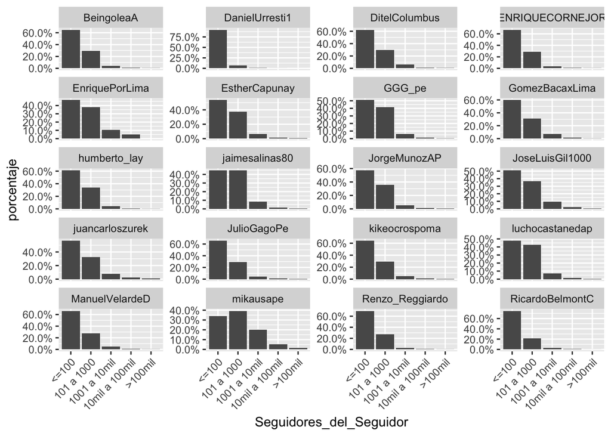

## De los amigos por los seguidores:

Los seguidores no son exclusivos. La siguiente tabla nos muestra que hay seguidores que siguen a muchos usuarios en Twitter:

|  | candiname | total | max_Sigue | min_Sigue | maxSigue_90pct |
| --- | --- | --- | --- | --- | --- |
| 1 | BeingoleaA | 19537 | 918447 | 1 | 1715 |
| 2 | DanielUrresti1 | 270373 | 1049648 | 0 | 456 |
| 3 | DitelColumbus | 15988 | 1049461 | 1 | 1741 |
| 4 | ENRIQUECORNEJOR | 39226 | 1049538 | 0 | 1449 |
| 5 | EnriquePorLima | 58 | 4505 | 2 | 1583 |
| 6 | EstherCapunay | 7837 | 388048 | 0 | 2261 |
| 7 | GGG_pe | 12853 | 85386 | 1 | 1974 |
| 8 | GomezBacaxLima | 1039 | 33083 | 0 | 2554 |
| 9 | humberto_lay | 18171 | 240362 | 1 | 1933 |
| 10 | jaimesalinas80 | 4445 | 1049441 | 1 | 2362 |
| 11 | JorgeMunozAP | 18920 | 918417 | 1 | 1937 |
| 12 | JoseLuisGil1000 | 6267 | 766814 | 0 | 2645 |
| 13 | juancarloszurek | 1715 | 918383 | 0 | 2380 |
| 14 | JulioGagoPe | 22039 | 1049458 | 1 | 1903 |
| 15 | kikeocrospoma | 2906 | 133339 | 0 | 1743 |
| 16 | luchocastanedap | 6673 | 4677588 | 1 | 2045 |
| 17 | ManuelVelardeD | 7875 | 20639 | 0 | 1428 |
| 18 | mikausape | 130 | 322682 | 7 | 3016 |
| 19 | Renzo_Reggiardo | 32926 | 1049600 | 1 | 1627 |
| 20 | RicardoBelmontC | 5308 | 161185 | 0 | 1470 |

Sin embargo, hay seguidores que sólo tienen **1 amigo**; es decir, sólo siguen al candidato.

A continuación, mostramos la distribución de la cantidad de *los amigos los seguidores* de cada candidato:

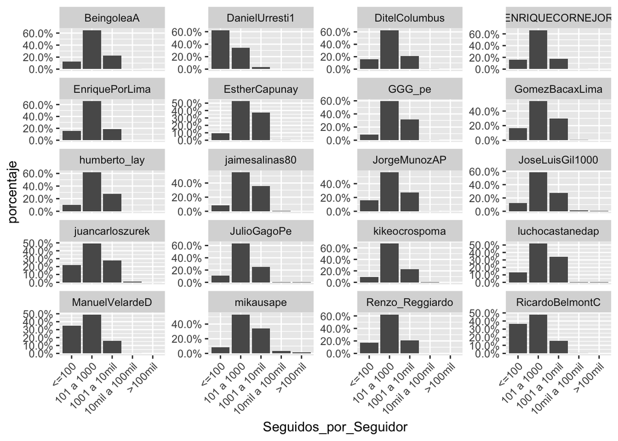

## Antiguedad en meses de seguidores:

Los seguidores de los candidatos, tienen diversa antiguedad en el Twitter; pero nótese que hay algunos que, desde el mes de agosto 2018, no tendrían ni un mes en Twitter.

|  | candiname | maxAntiguedadSeguidor | minAntiguedadSeguidor |
| --- | --- | --- | --- |
| 1 | BeingoleaA | 137 | 0 |
| 2 | DanielUrresti1 | 140 | 0 |
| 3 | DitelColumbus | 137 | 0 |
| 4 | ENRIQUECORNEJOR | 138 | 0 |
| 5 | EnriquePorLima | 135 | 0 |
| 6 | EstherCapunay | 139 | 0 |
| 7 | GGG_pe | 139 | 0 |
| 8 | GomezBacaxLima | 136 | 0 |
| 9 | humberto_lay | 137 | 0 |
| 10 | jaimesalinas80 | 137 | 0 |
| 11 | JorgeMunozAP | 140 | 0 |
| 12 | JoseLuisGil1000 | 137 | 0 |
| 13 | juancarloszurek | 139 | 0 |
| 14 | JulioGagoPe | 137 | 0 |
| 15 | kikeocrospoma | 137 | 0 |
| 16 | luchocastanedap | 137 | 0 |
| 17 | ManuelVelardeD | 139 | 0 |
| 18 | mikausape | 115 | 0 |
| 19 | Renzo_Reggiardo | 137 | 0 |
| 20 | RicardoBelmontC | 134 | 0 |

Si transformamos meses a años, podemos ver como se distribuye la antiguedad de los seguidores de los candidatos:

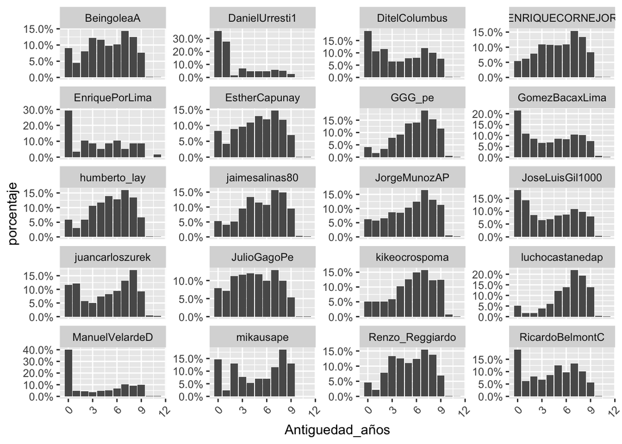

[MENU](https://ermperu.github.io/elecciones2018/)